# Lab 5: Time Series Analysis

#### Nate Miller

A company is launching a new change to their product. They have launched the product change in country I before they launch it in country II.

The data in `data/revenue.csv` shows their daily revenue in the two countries. The change occurred in country I on 9/1/16. It has not occurred in country II yet.

Your job is to:

1. Estimate the impact of the product change on the revenue in country I (`revenue1`).
   - Define what metric(s) you want to use to measure the impact
   - Predict what the revenue would be had there been no product change between 9/1/16 - 9/10/16
   - Estimate the value(s) of your metric(s)

```r
library(forecast)
```

```r
revenue = read.csv("~/GalvanizeGitHub/DSCI6008-student/DSCI6008-student/week5-TimeSeries/data/revenue.csv", stringsAsFactors=FALSE)
```

To measure the impact we can calculate the sum of the difference between the revenue with the product release (10 days post product release) and the upper 95% limit for the forecast without product release.

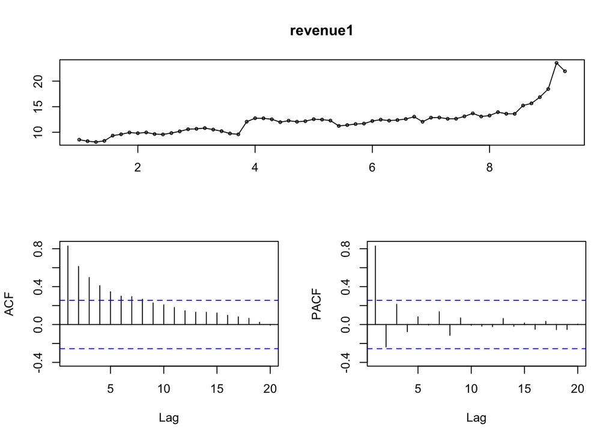

```r
revenue1 <- ts(revenue$revenue1, frequency=7)
tsdisplay(revenue1)
```

Remove the data post product release and predict revenue without product release

```r
reduced = revenue1[c(seq(0,length(revenue1) -10))]
```

Run the forecast to predict the revenue without the product release.

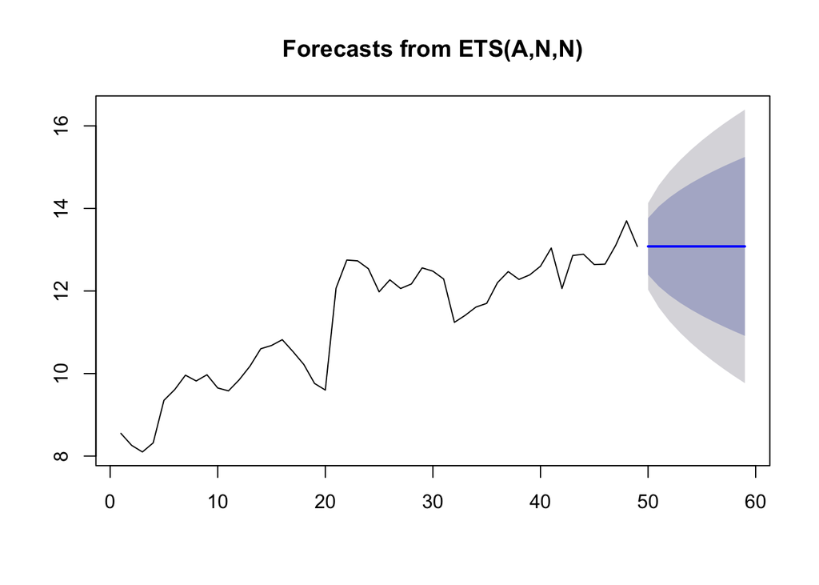

```r
fit_red <- ets(reduced)
fc_red <- forecast(fit_red, h=10)
plot(fc_red)
```

The mean forecasted revenue without the product release is 13.1. The 95% upper and lower bounds for this forecast are shown below.

```r
fc_red$upper[,2]
```

```
## Time Series:
## Start = 50
## End = 59
## Frequency = 1
##  [1] 14.12789 14.56184 14.89484 15.17556 15.42289 15.64650 15.85212
##  [8] 16.04351 16.22327 16.39329
```

```r
fc_red$lower[,2]
```

```
## Time Series:
## Start = 50
## End = 59
## Frequency = 1
##  [1] 12.032232 11.598281 11.265289 10.984560 10.737231 10.513628 10.308003
##  [8] 10.116612  9.936853  9.766832
```

The actual revenue for the 10 days post product release are

```r
with_prod = revenue$revenue1[c(seq(50,59))]
with_prod
```

```
##  [1] 13.27 13.94 13.62 13.61 15.24 15.65 16.86 18.45 23.56 21.94
```

Looking at the difference between the revenue with the product release and the upper 95% forecast for revenue without product release we can see the change in revenue due to the product release.

```r
product_gains = with_prod - fc_red$upper[,2]
product_gains
```

```
## Time Series:
## Start = 50
## End = 59
## Frequency = 1
##  [1] -0.857891565 -0.621842664 -1.274835009 -1.565563899 -0.182892627
##  [6]  0.003504194  1.007879268  2.406487858  7.336728831  5.546708305
```

What we see is that initially (5 days post-product release) there is no significance difference between the revenue with and without the product release, but during the final 5 days, the product release resulted in higher revenue.

```r
sum(product_gains)
```

```
## [1] 11.79828
```

Checking for autocorrelation between data points we can see that there isn’t a strong signal for autocorrellation (both visually and for the Box_Ljung test).

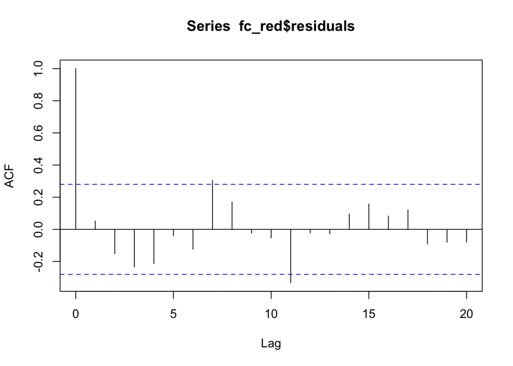

```r
acf(fc_red$residuals, lag.max=20)
```

```r
Box.test(fc_red$residuals, lag=20, type="Ljung-Box")
```

```
##
##  Box-Ljung test
##
## data:  fc_red$residuals
## X-squared = 28.592, df = 20, p-value = 0.09611
```

We can also look to see the forecast from an ARIMA model. I did not include a seasonal component given that the data was not that long. I ended up with a very similar output form the ARIMA model and similar conclusions.

```r
fit_noseason = auto.arima(reduced, seasonal=FALSE)
summary(fit_noseason)
```

```
## Series: reduced
## ARIMA(0,1,0)
##
## sigma^2 estimated as 0.2918:  log likelihood=-38.55
## AIC=79.09   AICc=79.18   BIC=80.96
##
## Training set error measures:
##                      ME      RMSE       MAE       MPE    MAPE      MASE
## Training set 0.09262347 0.5346136 0.3595622 0.7557268 3.16934 0.9800674
##                    ACF1
## Training set 0.05144362
```

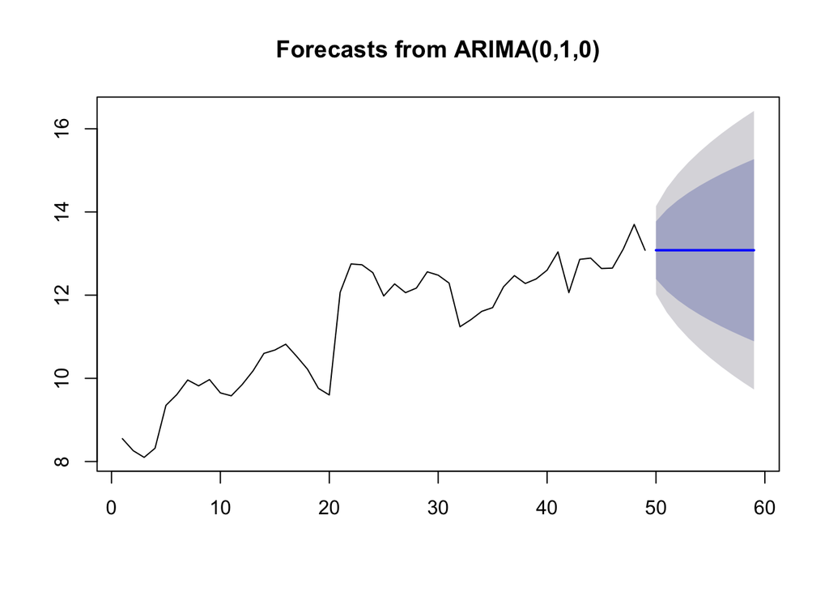

```r
plot(forecast(fit_noseason,h=10))
```

2. Predict the impact of the product change on the revenue in country II (`revenue2`) if they had launched the same product change between 9/1/16 - 9/10/16.
   - Predict the revenue in country II between 9/1/16 - 9/10/16 had there been a product change
   - Estimate the impact based on your predictions

Your work should be submitted in a `.Rmd` file.